# Feature Importance plots

# Formatting mrna names:

# The mrna names have both names and entrez ids joined with an underscore

# Splitting them and keeping only one of them will be enough

# In my analysis, the mirna names are in the format hsa-mir-000ab

# Get only the part after first dash, and keep the last dash

#setdiff(mirna_names, all_gene_sets$gene_symbol)

Grouping them by gene_name and adding them:

[output not shown]

GSEA

`r`r msigdbr_list = split(x = all_gene_sets$gene_symbol, f = all_gene_sets$gs_name)

```
There were 21 warnings (use warnings() to see them)
```

```
There were 15 pathways for which P-values were not calculated properly due to unbalanced gene-level statistic values
```

genes <- values_summarised %>% dplyr::select(features, anova) %>% deframe() fgseaRes_anova <- fgsea(pathways = msigdbr_list, stats = genes, nperm = 100000, nproc = 30)

topPathwaysUp <- fgseaRes_gcnlime[ES > 0][head(order(pval), n=10), pathway] topPathwaysDown <- fgseaRes_gcnlime[ES < 0][head(order(pval), n=10), pathway] topPathways_gcnlime <- c(topPathwaysUp, rev(topPathwaysDown))

topPathwaysUp <- fgseaRes_gcnshap[ES > 0][head(order(pval), n=10), pathway] topPathwaysDown <- fgseaRes_gcnshap[ES < 0][head(order(pval), n=10), pathway] topPathways_gcnshap <- c(topPathwaysUp, rev(topPathwaysDown))

topPathwaysUp <- fgseaRes_anova[ES > 0][head(order(pval), n=10), pathway] topPathwaysDown <- fgseaRes_anova[ES < 0][head(order(pval), n=10), pathway] topPathways_anova <- c(topPathwaysUp, rev(topPathwaysDown))

enriched_pathways <- tibble(anova=topPathways_anova, lime=topPathways_gcnlime, shap=topPathways_gcnshap)

#plotGseaTable(msigdbr_list[topPathways], genes, fgseaRes_gcnlime, gseaParam=0.5)

### The metric

`r`r summary(fgseaRes_anova$padj)

```
   Min. 1st Qu.  Median    Mean 3rd Qu.    Max.
0.01817 0.81905 0.90137 0.85202 0.94907 0.99980
```

`r`r summary(fgseaRes_gcnlime$padj)

```
    Min.  1st Qu.   Median     Mean  3rd Qu.     Max.     NA's
0.004182 1.000000 1.000000 0.960067 1.000000 1.000000       15
```

`r`r summary(fgseaRes_gcnshap$padj)

```
   Min. 1st Qu.  Median    Mean 3rd Qu.    Max.
0.00584 0.99986 0.99986 0.96341 0.99986 1.00000
```

`r`r count(fgseaRes_anova$padj < 0.1, na.rm = TRUE)

```
[1] 110
```

`r`r count(fgseaRes_gcnlime$padj < 0.1, na.rm = TRUE)

```
[1] 166
```

`r`r count(fgseaRes_gcnshap$padj < 0.1, na.rm = TRUE)

```
[1] 98
```

## Making table

`r`r grid.arrange(tableGrob(enrich_tibble, rows=NULL))

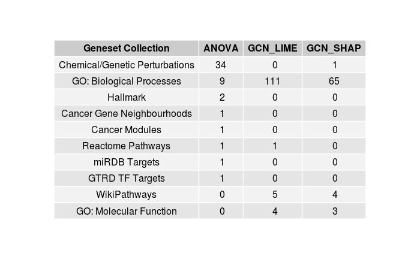

Try to subset msigdbr and then run:

`r`r enriched_pathways_c6 <- tibble(anova=topPathways_anova, lime=topPathways_gcnlime, shap=topPathways_gcnshap)

[output not shown]

Try other disease gene sets:

#### DisGeNET

[output not shown]

`r`r pathways_list = split(x = DisGeNET$geneSymbol, f = DisGeNET$diseaseName)

genes <- values_summarised %>% dplyr::select(features, lime) %>% deframe() fgseaRes_gcnlime <- fgsea(pathways = pathways_list, stats = genes, nperm = 100000, nproc = 30)

```
There were 1 pathways for which P-values were not calculated properly due to unbalanced gene-level statistic values
```

`r`r genes <- values_summarised %>% dplyr::select(features, shap) %>% deframe() fgseaRes_gcnshap <- fgsea(pathways = pathways_list, stats = genes, nperm = 100000, nproc = 30)

genes <- values_summarised %>% dplyr::select(features, anova) %>% deframe() fgseaRes_anova <- fgsea(pathways = pathways_list, stats = genes, nperm = 100000, nproc = 30)

summary(fgseaRes_anova$padj)

```
   Min. 1st Qu.  Median    Mean 3rd Qu.    Max.
 0.1195  0.9987  0.9987  0.9981  0.9987  0.9997
```

`r`r summary(fgseaRes_gcnlime$padj)

```
    Min.  1st Qu.   Median     Mean  3rd Qu.     Max.     NA's
0.001814 0.999804 0.999804 0.968838 0.999804 1.000000        1
```

`r`r summary(fgseaRes_gcnshap$padj)

```
    Min.  1st Qu.   Median     Mean  3rd Qu.     Max.
0.005449 0.998937 0.998937 0.988324 0.998937 1.000000
```

`r`r count(fgseaRes_anova$padj < 0.05, na.rm = TRUE)

```
[1] 0
```

`r`r count(fgseaRes_gcnlime$padj < 0.05, na.rm = TRUE)

```
[1] 114
```

`r`r count(fgseaRes_gcnshap$padj < 0.05, na.rm = TRUE)

```
[1] 48
```

`r`r topPathwaysUp <- fgseaRes_gcnlime[ES > 0][head(order(padj), n=10), pathway] topPathwaysDown <- fgseaRes_gcnlime[ES < 0][head(order(padj), n=10), pathway] topPathways_gcnlime <- c(topPathwaysUp, rev(topPathwaysDown))

topPathwaysUp <- fgseaRes_gcnshap[ES > 0][head(order(padj), n=10), pathway] topPathwaysDown <- fgseaRes_gcnshap[ES < 0][head(order(padj), n=10), pathway] topPathways_gcnshap <- c(topPathwaysUp, rev(topPathwaysDown))

topPathwaysUp <- fgseaRes_anova[ES > 0][head(order(padj), n=10), pathway] topPathwaysDown <- fgseaRes_anova[ES < 0][head(order(padj), n=10), pathway] topPathways_anova <- c(topPathwaysUp, rev(topPathwaysDown))

enriched_pathways_disgenet <- tibble(anova=topPathways_anova, lime=topPathways_gcnlime, shap=topPathways_gcnshap)

#### DriverV3

Applied for the dataset online

Making tables:

`r`r fgseaRes_anova$pathway[fgseaRes_anova$padj < 0.05]

```
character(0)
There were 26 warnings (use warnings() to see them)
```

`r`r fgseaRes_gcnlime$pathway[fgseaRes_gcnlime$padj < 0.05]

```
[1] \UCEC\
```

`r`r fgseaRes_gcnshap$pathway[fgseaRes_gcnshap$padj < 0.05]

```
[1] \STAD\ \UCEC\
```

`r`r fgseaRes_svmlime$pathway[fgseaRes_svmlime$padj < 0.05]

```
[1] \UCEC\ \UCS\
```

```
There were 26 warnings (use warnings() to see them)
```

[output not shown]

`r`r length(breast_cancer_genes)

```
[1] 2427
```

`r`r length(intersect(uterine_cancer_genes, breast_cancer_genes))

```
[1] 1321
```

`r`r length(unique(values$features))

```
[1] 2217
```

`r`r length(intersect(unique(values$features), breast_cancer_genes))

```
[1] 211
```

`r`r length(intersect(unique(values$features), uterine_cancer_genes))

```
[1] 594
```